# GWP3

## R Markdown

This is the document following the python ipynb html file:

```r
library(tidyverse)
library(evir)
library(vars)
library(parallel)
library(quantmod)
```

## TASK 3.4: Use a common metric (BUT NOT 2 SIGMA),

## or derive your own, to identify an extreme value. Explain your reasoning.

## Apply your metric to each of the return series.

# implementing the GEV Distribution using the Gold returns

```r
ETF = read.csv("GWP3/SCHF_Returns.csv", header = TRUE)
Gold = read.csv("GWP3/GLD_Returns.csv", header = TRUE)
Bitcoin = read.csv("GWP3/BTC_Returns.csv", header = TRUE)

Gold_Returns <- Gold$Log.Returns
ETF_Returns <- ETF$Log.Returns
Bitcoin_Returns  <-  Bitcoin$Log.Returns
```

# 2.1 ’Compute the daily returns of your Gold ETF, your Equity ETF, and bitcoin of April 2020 through Dec 2020

#3.1 Compute the returns for each series.  
#3.2 Similarly, compute the kurtosis for each series. #3.3 Use a common metric (BUT NOT 2 SIGMA), or derive your own, to identify an extreme value. Explain your reasoning.

#3.4 Apply your metric to each of the return series.

```r
negative_gold_returns <- -Gold_Returns
Gold_GEV <- gev(negative_gold_returns, block = 21)
Gold_GEV
```

```
## $n.all
## [1] 190
##
## $n
## [1] 10
##
## $data
##  [1]  1.9608471  1.4683617  2.0483688  0.9496636  5.5189730  2.1843338
##  [7]  1.6275167  4.5280853  1.7241806 -0.7626028
##
## $block
## [1] 21
##
## $par.ests
##         xi      sigma         mu
## -0.1376366  1.4911712  1.4440888
##
## $par.ses
##        xi     sigma        mu
## 0.2144792 0.3613259 0.5238335
##
## $varcov
##             [,1]        [,2]        [,3]
## [1,]  0.04600132 -0.03038681 -0.04100854
## [2,] -0.03038681  0.13055641  0.03707266
## [3,] -0.04100854  0.03707266  0.27440150
##
## $converged
## [1] 0
##
## $nllh.final
## [1] 19.00439
##
## attr(,"class")
## [1] "gev"
```

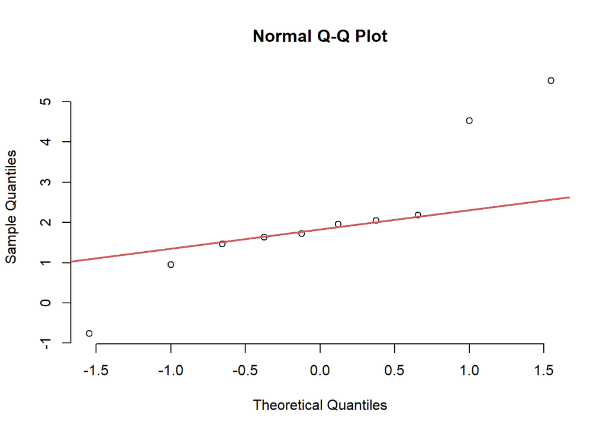

```r
qqnorm(Gold_GEV$data, pch = 1, frame = FALSE)
qqline(Gold_GEV$data, col = "indianred", lwd = 2)
```

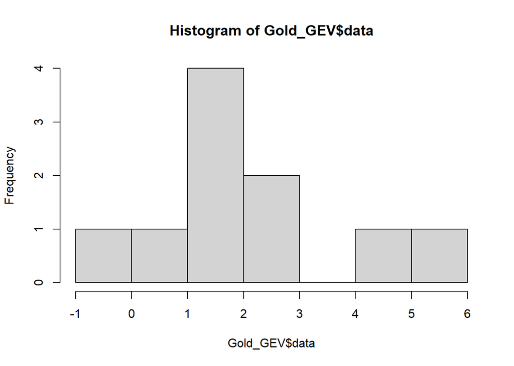

```r
hist(Gold_GEV$data)
```

```r
negative_equity_returns <- -ETF_Returns
ETF_GEV <- gev(negative_equity_returns, block = 21)
ETF_GEV
```

```
## $n.all
## [1] 191
##
## $n
## [1] 10
##
## $data
##  [1] 4.836454 2.321834 5.645585 1.511689 1.917826 2.429529 2.954282 1.477133
##  [9] 2.143244 0.691853
##
## $block
## [1] 21
##
## $par.ests
##       xi    sigma       mu
## 0.125679 1.002834 1.875771
##
## $par.ses
##        xi     sigma        mu
## 0.2692052 0.2776226 0.3621315
##
## $varcov
##             [,1]        [,2]        [,3]
## [1,]  0.07247142 -0.01386984 -0.03425803
## [2,] -0.01386984  0.07707431  0.05153606
## [3,] -0.03425803  0.05153606  0.13113919
##
## $converged
## [1] 0
##
## $nllh.final
## [1] 16.56852
##
## attr(,"class")
## [1] "gev"
```

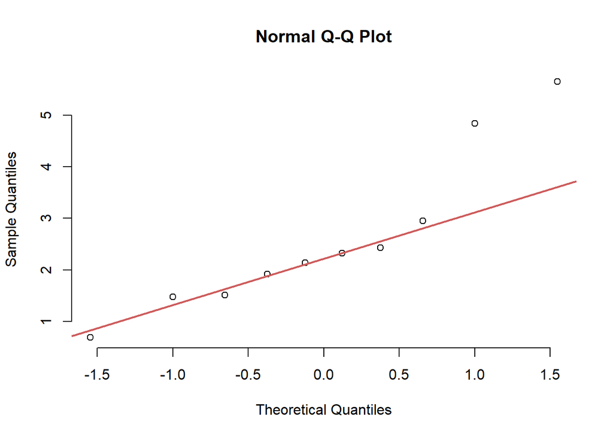

```r
qqnorm(ETF_GEV$data, pch = 1, frame = FALSE)
qqline(ETF_GEV$data, col = "indianred", lwd = 2)
```

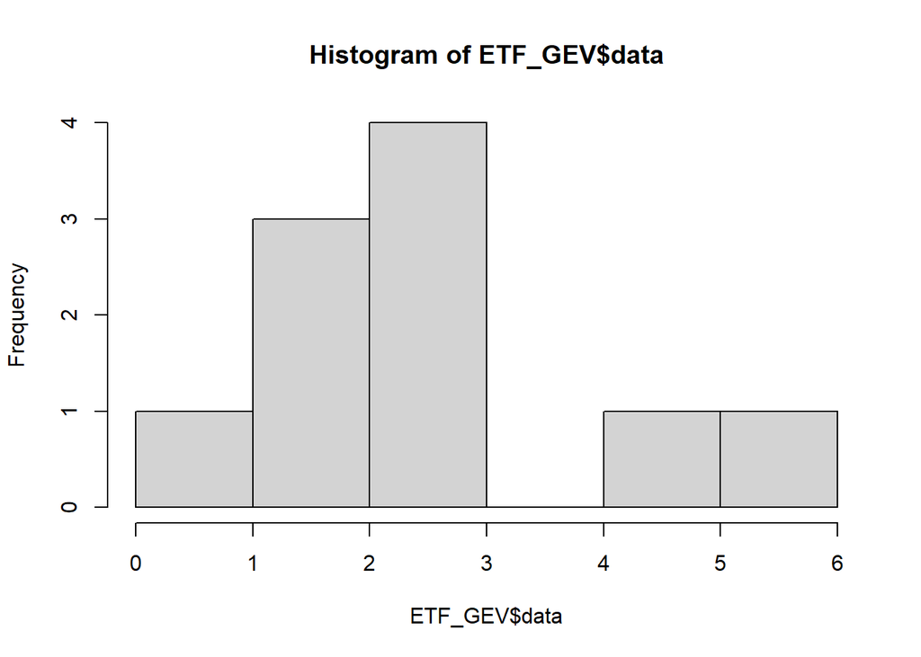

```r
hist(ETF_GEV$data)
```

```r
negative_btc_returns <- -Bitcoin_Returns
BTC_GEV <- gev(negative_btc_returns, block = 21)
BTC_GEV
```

```
## $n.all
## [1] 275
##
## $n
## [1] 14
##
## $data
##  [1]  6.1652646  9.1338750  6.4749475  5.7155719  3.3370923  6.1911857
##  [7]  4.0161113 10.8024908  4.4493311  1.5183968  4.8176141  8.8205254
## [13]  2.9138077 -0.5558802
##
## $block
## [1] 21
##
## $par.ests
##        xi     sigma        mu
## -0.320550  2.970411  4.289220
##
## $par.ses
##        xi     sigma        mu
## 0.2044987 0.6419296 0.8887998
##
## $varcov
##             [,1]         [,2]         [,3]
## [1,]  0.04181973 -0.079990743 -0.076378992
## [2,] -0.07999074  0.412073636  0.006764829
## [3,] -0.07637899  0.006764829  0.789965114
##
## $converged
## [1] 0
##
## $nllh.final
## [1] 34.84954
##
## attr(,"class")
## [1] "gev"
```

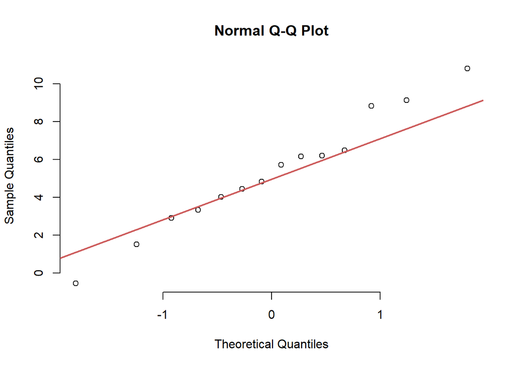

```r
qqnorm(BTC_GEV$data, pch = 1, frame = FALSE)
qqline(BTC_GEV$data, col = "indianred", lwd = 2)
```

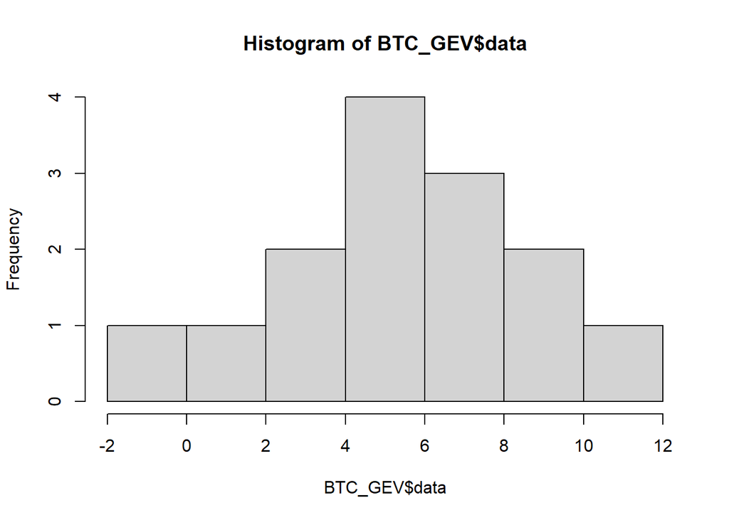

```r
hist(BTC_GEV$data)
```

```r
Equity_Returns_Q2 <- subset(ETF, Date >= "2020-04-01" & Date  <= "2020-04-30")
Bitcoin_Returns_Q2 <- subset(Bitcoin, Date >= "2020-04-01" & Date  <= "2020-04-30")
Equity_Returns_Q3 <- subset(ETF,  Date >= "2020-07-01" & Date  <= "2020-09-30")
Bitcoin_Returns_Q3 <- subset(Bitcoin,  Date >= "2020-07-01" & Date  <= "2020-09-30")
Equity_Returns_Q4 <- subset(ETF, Date >= "2020-10-01" & Date  <= "2020-12-31")
```

```r
Bitcoin_Returns_Q4 <- subset(Bitcoin, Date >= "2020-10-01" & Date  <= "2020-04-31")
```